# Home Work 3

| manufacturer | model | displ | year | cyl | trans | drv | cty | hwy | fl | class |
| --- | --- | --- | --- | --- | --- | --- | --- | --- | --- | --- |
| audi | a4 | 1.8 | 1999 | 4 | auto(l5) | f | 18 | 29 | p | compact |
| audi | a4 | 1.8 | 1999 | 4 | manual(m5) | f | 21 | 29 | p | compact |
| audi | a4 | 2.0 | 2008 | 4 | manual(m6) | f | 20 | 31 | p | compact |
| audi | a4 | 2.0 | 2008 | 4 | auto(av) | f | 21 | 30 | p | compact |
| audi | a4 | 2.8 | 1999 | 6 | auto(l5) | f | 16 | 26 | p | compact |
| audi | a4 | 2.8 | 1999 | 6 | manual(m5) | f | 18 | 26 | p | compact |
| audi | a4 | 3.1 | 2008 | 6 | auto(av) | f | 18 | 27 | p | compact |
| audi | a4 quattro | 1.8 | 1999 | 4 | manual(m5) | 4 | 18 | 26 | p | compact |
| audi | a4 quattro | 1.8 | 1999 | 4 | auto(l5) | 4 | 16 | 25 | p | compact |
| audi | a4 quattro | 2.0 | 2008 | 4 | manual(m6) | 4 | 20 | 28 | p | compact |

[output cut: 224 more lines]

# 3.3.1

#### Q1. What’s gone wrong with this code? Why are the points not blue?

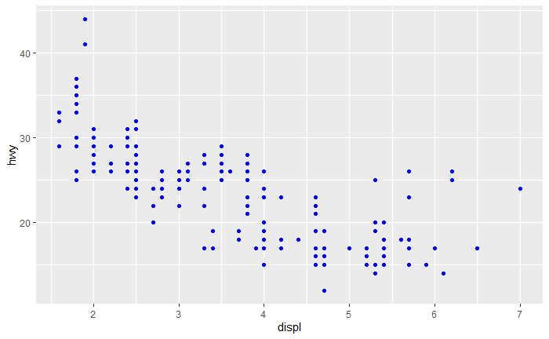

```r
ggplot(data = mpg) +
  geom_point(mapping = aes(x = displ, y = hwy), color = "blue")
```

Ans. The color parameter is taken in aesthetic, which defines the color for cateogrical variable. Here, to make the points blue we need to pass color as a parameter to geom_point function instead of aes.

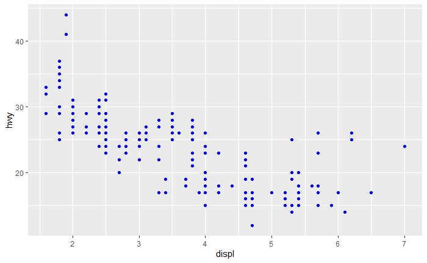

```r
ggplot(data = mpg) +
  geom_point(mapping = aes(x = displ, y = hwy) , color = "blue")
```

#### Q2. Which variables in mpg are categorical? Which variables are continuous? (Hint: type ?mpg to read the documentation for the dataset). How can you see this information when you run mpg?

```r
?mpg
# How can you see this information when you run mpg?
str(mpg)
```

```
Classes ‘tbl_df’, ‘tbl’ and 'data.frame':   234 obs. of  11 variables:
 $ manufacturer: chr  "audi" "audi" "audi" "audi" ...
 $ model       : chr  "a4" "a4" "a4" "a4" ...
 $ displ       : num  1.8 1.8 2 2 2.8 2.8 3.1 1.8 1.8 2 ...
 $ year        : int  1999 1999 2008 2008 1999 1999 2008 1999 1999 2008 ...
 $ cyl         : int  4 4 4 4 6 6 6 4 4 4 ...
 $ trans       : chr  "auto(l5)" "manual(m5)" "manual(m6)" "auto(av)" ...
 $ drv         : chr  "f" "f" "f" "f" ...
 $ cty         : int  18 21 20 21 16 18 18 18 16 20 ...
 $ hwy         : int  29 29 31 30 26 26 27 26 25 28 ...
 $ fl          : chr  "p" "p" "p" "p" ...
 $ class       : chr  "compact" "compact" "compact" "compact" ...
```

```r
##Which variables in mpg are categorical?
## Categorical Variable - manufacturer, model , trans,drv, fl, class

## Which variables are continuous?
## Continuous Variable -year, displ, cyl, cty, hwy,
```

#### Q3. Map a continuous variable to color, size, and shape. How do these aesthetics behave differently for categorical vs. continuous variables?

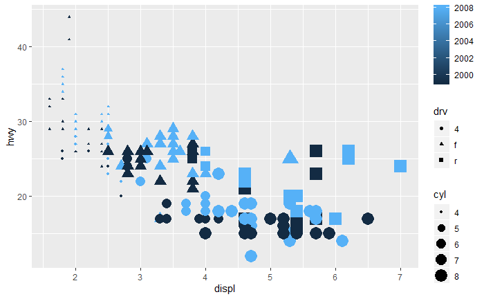

```r
ggplot(data = mpg) +
  geom_point(mapping = aes(x = displ, y = hwy, color = year, size =cyl, shape=drv))
```

#### Q4. What happens if you map the same variable to multiple aesthetics?

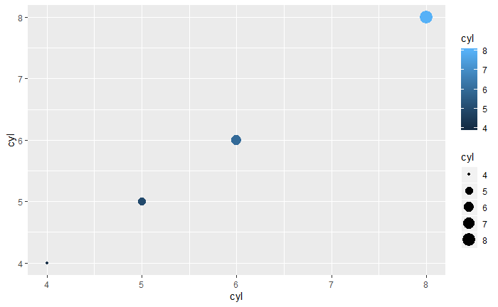

```r
ggplot(data = mpg) +
  geom_point(mapping = aes(x = cyl, y = cyl, color= cyl, size = cyl) )
```

#### Q5. What does the stroke aesthetic do? What shapes does it work with? (Hint: use ?geom_point)

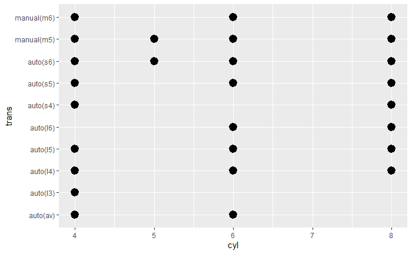

```r
ggplot(data = mpg) +
  geom_point(mapping = aes(x = cyl, y = trans, stroke = 3) )
```

#### Q6. What happens if you map an aesthetic to something other than a variable name, like aes(colour = displ < 5)? Note, you’ll also need to specify x and y.

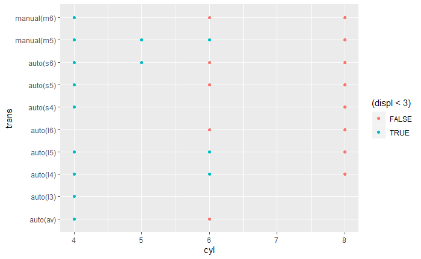

```r
ggplot(data = mpg) +
  geom_point(mapping = aes(x = cyl, y = trans, color = (displ < 3) ))
```

# 3.5.1

#### Q1.What happens if you facet on a continuous variable?

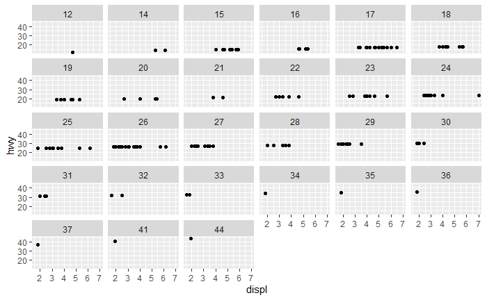

```r
ggplot(data = mpg) +
  geom_point(mapping = aes(x = displ, y = hwy)) +
  facet_wrap(~hwy)
```

#### Q2.What do the empty cells in plot with facet_grid(drv ~ cyl) mean? How do they relate to this plot?

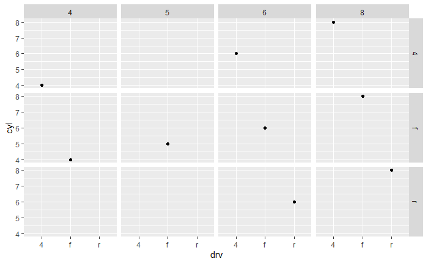

```r
ggplot(data = mpg) +
  geom_point(mapping = aes(x = drv, y = cyl)) +
  facet_grid(drv ~ cyl)
```

#### Q3.What plots does the following code make? What does . do?

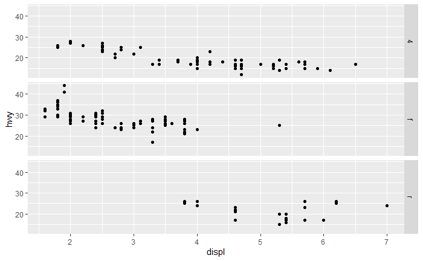

```r
ggplot(data = mpg) +
  geom_point(mapping = aes(x = displ, y = hwy)) +
  facet_grid(drv ~ .)
```

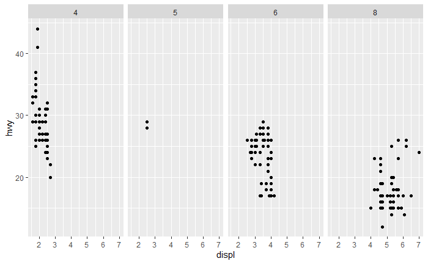

```r
ggplot(data = mpg) +
  geom_point(mapping = aes(x = displ, y = hwy)) +
  facet_grid(. ~ cyl)
```

#### Q4.

#### Q5.

#### Q6.

# 3.6.1

#### Q1.

#### Q2.

#### Q3.

#### Q4.

#### Q5.

#### Q6.

# 3.7.1

#### Q1.

#### Q2.

#### Q3.

#### Q4.

#### Q5.

# 3.9.1

#### Q1.

#### Q2.

#### Q3.

#### Q4.

# 7.5.1.1

#### Q1.

#### Q2.

#### Q3.

#### Q4.

#### Q5.

#### Q6.